# Untitled

projee

13 01 2021

**Kutuphaneler**

**Datayi Tanima** Oncellikle datayi cektik.

```r
attach(df1)
df1$demographic <- df1$demographic[,-c(14:17,8)]
df1$demographic <- df1$demographic %>%
                 mutate_if(is.character,as.factor)

df1$demographic$year_of_death <-as.Date(as.character(demographic$year_of_death),format="%Y")

class(df1$demographic$year_of_death)
```

```
## [1] "Date"
```

```r
df1$demographic$year_of_birth<-as.Date(as.character(demographic$year_of_birth),format="%Y")
class(df1$demographic$year_of_birth)
```

```
## [1] "Date"
```

```r
df1$demographic <- df1$demographic[,-c(14:17,8)]


data1 <- data.frame(df1,df2)

head(df1$demographic$weight)
```

[output not shown]

Gerekli donusumleri yaptik.

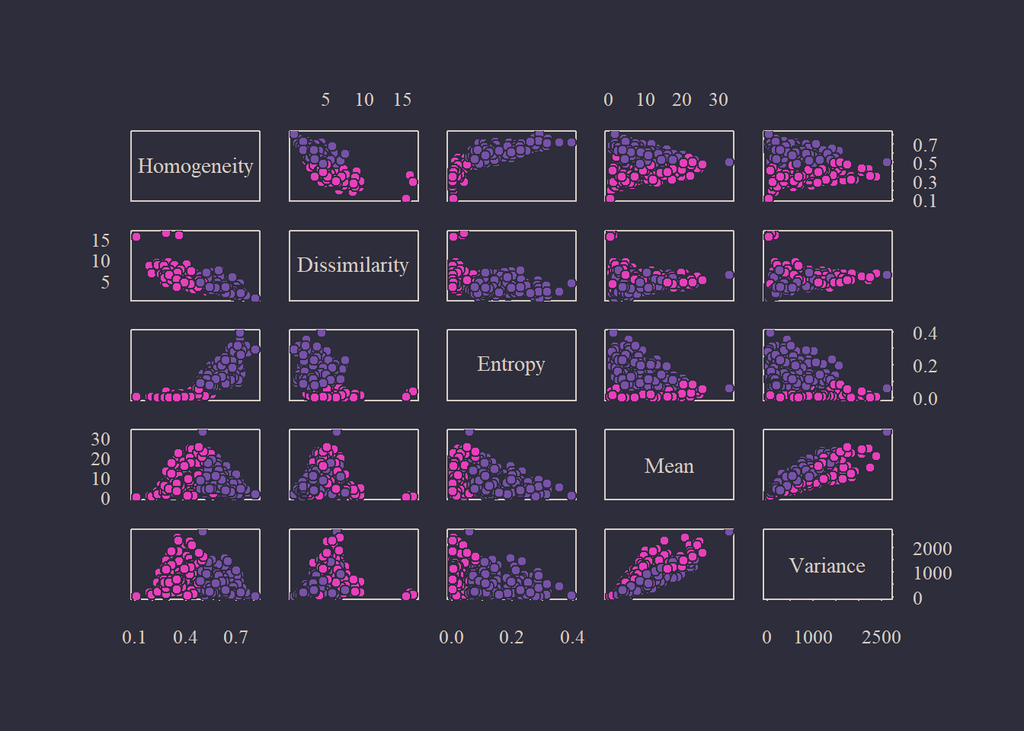

```r
df4<- read_csv("C:/Users/Dell/Dropbox/My PC (DESKTOP-EB8G4PC)/Desktop/GitHub/Brain Tumor.csv")


d<-df4%>%
  select(Homogeneity,Dissimilarity,Entropy,Mean,Variance)


basetheme("royal")
pairs(d, bg=lab2col(df4$Class), col=0)
```

Datamizdaki mri goruntulerini daha iyi anlamak icin df4 deki dataframeden class hastaliga sahip ve sahip olmayan kisilerin mri goruntulerinin diger degiskenlerle olan iliskilerini anlamak icin grafik cizdirdik.

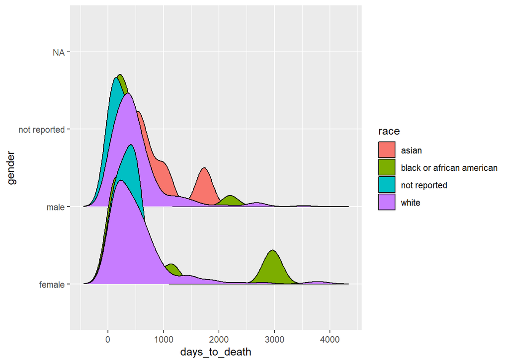

```r
library(ggplot2)
library(ggridges)
ggplot(df1$demographic, aes(x = days_to_death, y =gender,fill=race )) + geom_density_ridges()
```

Datadaki irk degiskenine bakmak icin grafik cizdirdik.

[output not shown]

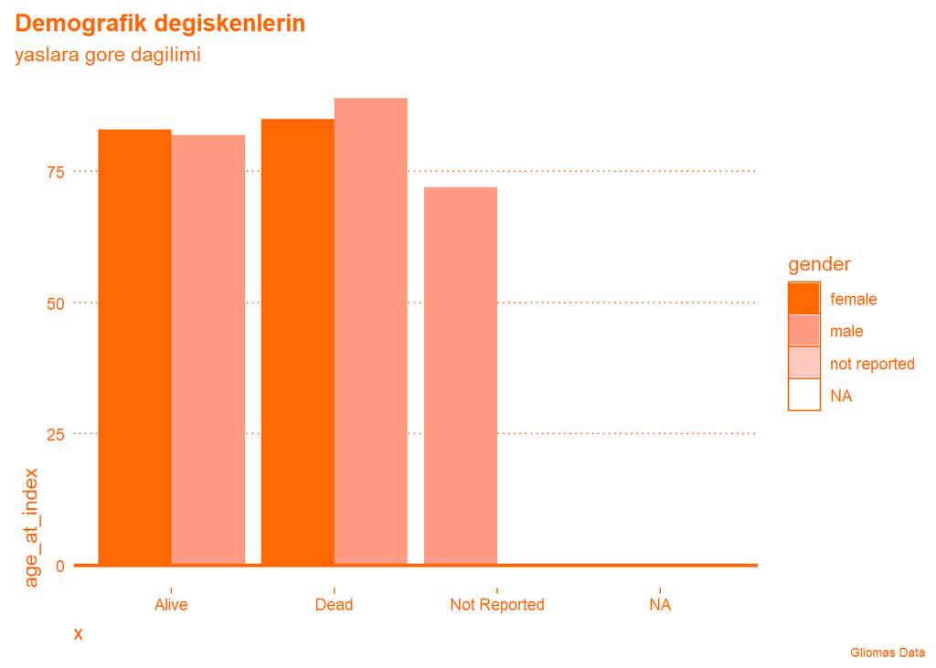

```r
library(ggplot2)
library(gghighcontrast)

data<-df1$demographic %>%
  select(gender,race,age_at_index ,vital_status , ethnicity)


plot_bar_high_contrast <-
  function(x,
           foreground_color = "#ff6700",
           background_color = "white") {
    plot <- ggplot(data, aes(x = x, y= age_at_index,fill=gender)) +
      geom_bar(stat = "identity",
               position = position_dodge()) +
      geom_hline(yintercept = 0,
                 color = foreground_color,
                 size = 1) +
      theme_high_contrast(
        base_family = "InputMono",
        foreground_color = foreground_color,
        background_color = background_color
      ) +
      scale_fill_high_contrast(foreground_color = foreground_color) +
      labs(title = paste0("Demografik degiskenlerin"),
           subtitle =paste0("yaslara gore dagilimi"),
           caption = "Gliomas Data")
    return(plot)
  }
p <- plot_bar_high_contrast(data$vital_status)
p
```

Buradaka ise demografik degiskenlerin yasa gore dagilimlarini bulabilmek icin grafik cizdiren bir fonk yazdik.

```r
# remotes::install_github("R-CoderDotCom/ggcats@main")


df1$demographic = mutate(df1$demographic,hastalikyas = case_when(df1$demographic$age_at_index<=17~"Ergen yas araligi",
                                            df1$demographic$age_at_index>18 & df1$demographic$age_at_index<=45~"Genc yas araligi",
                                            df1$demographic$age_at_index>46 & df1$demographic$age_at_index<=65~"Orta yas araligi",
                                            df1$demographic$age_at_index>65 & df1$demographic$age_at_index<=100~"Yasli",
                                            is.na(df1$demographic$age_at_index==TRUE)~NA_character_))

table(df1$demographic$hastalikyas)
```

```
##
## Ergen yas araligi  Genc yas araligi  Orta yas araligi             Yasli
##                 5                97               298               187
```

yaslari kendi aralarinda kategorilere ayirdik.

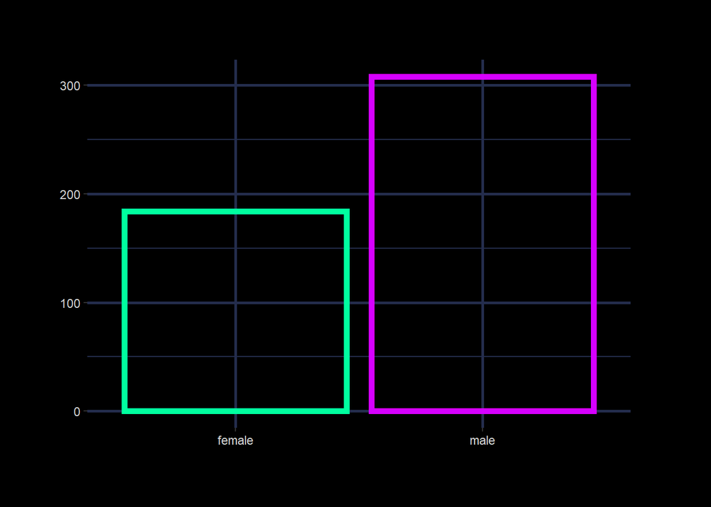

```r
df10<- df1$demographic %>%
   filter(vital_status=="Dead")%>%
  group_by(gender)%>%
  count()
df11 <- data.frame(x = df10$gender,
                 y = df10$n)

cyber_bars(df11, area = FALSE, bg.col = "black")
```

Bu kisimda olen kisilerin cinsiyetlerini anlamaya calistik.

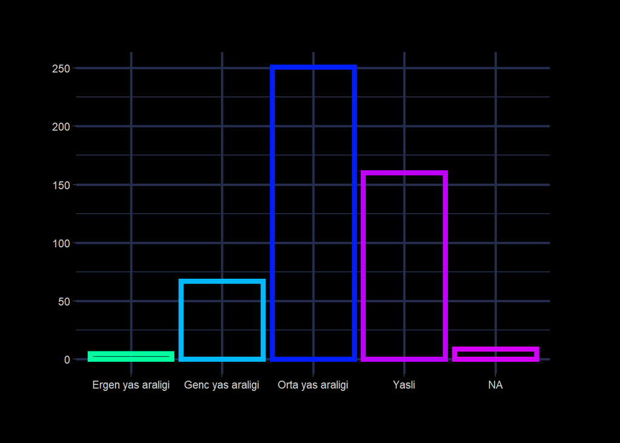

```r
df8<- df1$demographic %>%
  filter(vital_status=="Dead")%>%
  group_by(hastalikyas)%>%
  count()

df9 <- data.frame(x = df8$hastalikyas,
                 y = df8$n)

cyber_bars(df9, area = FALSE, bg.col = "black")
```

Bu kisimda ise hastalik yuzunden olen kisilerin yas araliklarina bakarak hangi yas araligindaki kisilerin daha cok vefat ettigini anlamaya calistik.

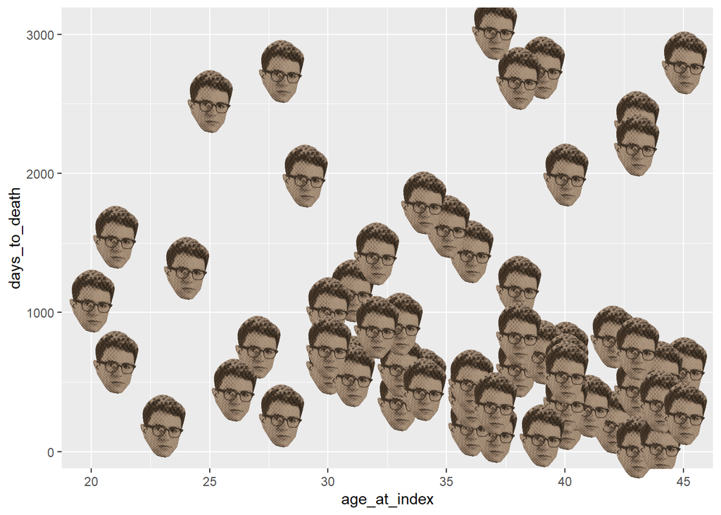

```r
genc_olum <-df1$demographic%>%
  filter(hastalikyas=="Genc yas araligi") %>%
  filter(vital_status=="Dead") %>%
  select(age_at_index,days_to_death,race,gender)
ggplot(genc_olum) +
  geom_bernie(aes(age_at_index,days_to_death), bernie = "young")
```

Burada ise genc yasta olenlerin teshisten- olumune kadar gecen surelerine baktik

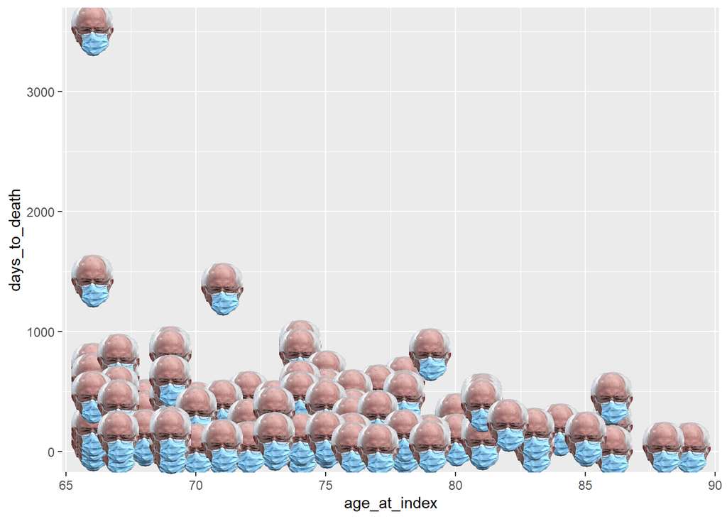

```r
yasli_olum <-df1$demographic%>%
  filter(hastalikyas=="Yasli") %>%
  filter(vital_status=="Dead") %>%
  select(days_to_death,race,gender,age_at_index)


ggplot(yasli_olum) +
  geom_bernie(aes(age_at_index,days_to_death), bernie = "head")
```

Burada ise yasli olumlerinin olume kadar gecen surelerine baktik genis bir skalada olmasi ilgimizi cekti.

[output not shown]

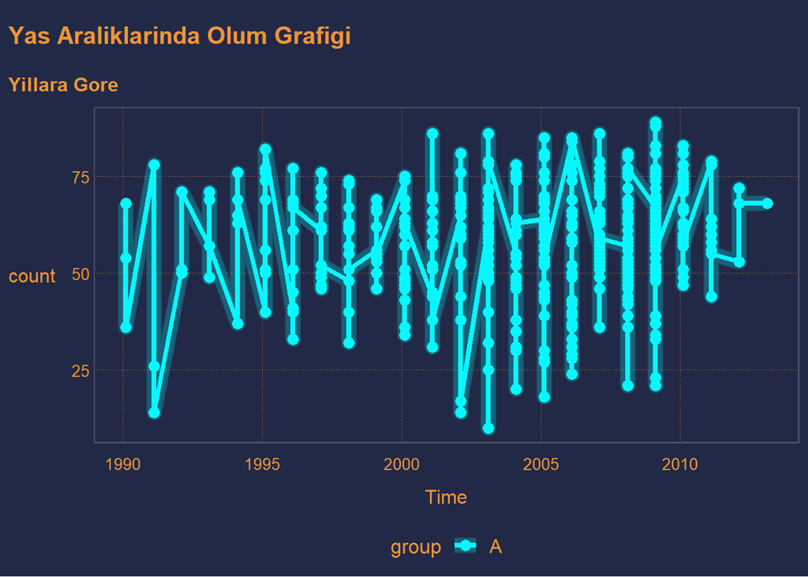

```r
df6 = data.frame(A=c(df1$demographic$age_at_index),
               Time=c(df1$demographic$year_of_deat)) %>%
pivot_longer(cols = c(A),names_to = "group", values_to = "count")


library(ggCyberPunk)
library(ggplot2)
df6 %>%
   ggplot(aes(x=Time, y = count, color = group, fill= group))+
     geom_glowing_line()+
     theme_cyberpunk()+
     scale_color_cyberpunk()+
  ggtitle("Yas Araliklarinda Olum Grafigi", subtitle = "Yillara Gore ")
```

```r
library(tidyverse)
kanser_geni <- df3 %>%
             filter(is_cancer_gene_census == "true")%>%
             count()
kanser_geni
```

| n |
| --- |
| 575 |

Datayi incelerken bazi genlerin kanserle iliskili oldugunu varsaydiklarini gorduk. Biz de bu genlerin sayisini gormeye calistik.

```r
Pten <- read.delim("C:/Users/Dell/Dropbox/My PC (DESKTOP-EB8G4PC)/Desktop/Pten.txt")
nchar(Pten)
```

```
##   PTEN
## 152350
```

```r
head(Pten)
```

|  | PTEN |
| --- | --- |
| 1 |  |
| 2 | 1 aggtgctgtt ttttgtgatg ccttagaggc cagaaggatg ttttgaaggg gaaaattgta |
| 3 | 61 ggagttaggc agagcagggt tttggctcct tctcaatgtc cctctaccta gacaaattcg |
| 4 | 121 ggctattctg cagaggttgc agtgagccat gatcacgtca ctgcactcca gcctgaggaa |
| 5 | 181 cagagggaga ctccgtctca aaaaaaaaaa aaaaaaaaaa aaaaaaaaaa atttctgcct |
| 6 | 241 actctatgaa gcacctggta ggtgtcccaa tattttctgg tatatgggaa ttaccttttt |

```r
pten1 <- Pten[-1,]
head(pten1)
```

```
## [1] "        1 aggtgctgtt ttttgtgatg ccttagaggc cagaaggatg ttttgaaggg gaaaattgta"
## [2] "       61 ggagttaggc agagcagggt tttggctcct tctcaatgtc cctctaccta gacaaattcg"
## [3] "      121 ggctattctg cagaggttgc agtgagccat gatcacgtca ctgcactcca gcctgaggaa"
## [4] "      181 cagagggaga ctccgtctca aaaaaaaaaa aaaaaaaaaa aaaaaaaaaa atttctgcct"
## [5] "      241 actctatgaa gcacctggta ggtgtcccaa tattttctgg tatatgggaa ttaccttttt"
## [6] "      301 ctattattgg aaggtctaaa aagcaaacaa tgtgctccat atggctagag ttagtattaa"
```

```r
# Pten genindeki t varyasyonlari
separator <- char_class(" ")
pattern_t_pten <- zero_or_more(separator) %R% one_or_more("t") %R%zero_or_more(separator)
pten_pt <- str_extract(pten1, pattern=pattern_t_pten)

table(pten_pt)
```

```
## pten_pt
##            t           tt          ttt         tttt        ttttt       tttttt
##          422          144           68           30           15            2
##      ttttttt     tttttttt    ttttttttt  tttttttttt             t           t
##            5            1            1            4          794           20
##           tt          tt           ttt         ttt          tttt        tttt
##          245            8           96            5           38            5
##        ttttt       ttttt        tttttt      tttttt     tttttttt    ttttttttt
##           12            3            4            1            1            1
```

```r
# Pten genindeki t sayisi
pten_pt_count <- str_count(pten1, pattern=pattern_t_pten)

pten_pt_count <-sum(pten_pt_count)

# Pten genindeki a varyasyonlari

pattern_aa_pten <- zero_or_more(separator) %R% one_or_more("a") %R%zero_or_more(separator)
pten_paa <- str_extract(pten1, pattern=pattern_aa_pten)

table(pten_paa)
```

```
## pten_paa
##         a        aa       aaa      aaaa     aaaaa    aaaaaa   aaaaaaa         a
##       375       120        48        18         4         1         1       924
##        a         aa       aa        aaa      aaa       aaaa     aaaa      aaaaa
##        36       234         8        92         7        32         1        12
##    aaaaa     aaaaaa   aaaaaa  aaaaaaaa
##         3         4         2         1
```

```r
# Pten genindeki t sayisi
pten_paa_count <- str_count(pten1, pattern=pattern_aa_pten)

pten_paa_count <-sum(pten_paa_count)

# Pten genindeki g varyasyonlari

pattern_g_pten <- zero_or_more(separator) %R% one_or_more("g") %R%zero_or_more(separator)
pten_pg <- str_extract(pten1, pattern=pattern_g_pten)

table(pten_pg)
```

```
## pten_pg
##       g      gg     ggg    gggg  gggggg       g      g       gg     gg      ggg
##     355      57      16       1       1    1136      63     222      13      44
##    ggg     gggg   gggg
##       4      10       2
```

```r
# Pten genindeki g sayisi
pten_pg_count <- str_count(pten1, pattern=pattern_g_pten)

pten_pg_count <- sum(pten_pg_count)


# Pten genindeki c varyasyonlari

pattern_c_pten <- zero_or_more(separator) %R% one_or_more("c") %R%zero_or_more(separator)
pten_pc <- str_extract(pten1, pattern=pattern_c_pten)

table(pten_pc)
```

```
## pten_pc
##      c     cc    ccc   cccc  ccccc      c     c      cc    cc     ccc   ccc
##    320     72     15      6      1   1141     90    216      9     42      5
##   cccc  cccc
##      5      3
```

```r
# Pten genindeki c sayisi
pten_pc_count <- str_count(pten1, pattern=pattern_c_pten)

pten_pc_count <- sum(pten_pc_count)

table(pten_paa_count,pten_pg_count ,pten_pc_count ,pten_pt_count )
```

```
## , , pten_pc_count = 15686, pten_pt_count = 26195
##
##               pten_pg_count
## pten_paa_count 17848
##          23522     1
```

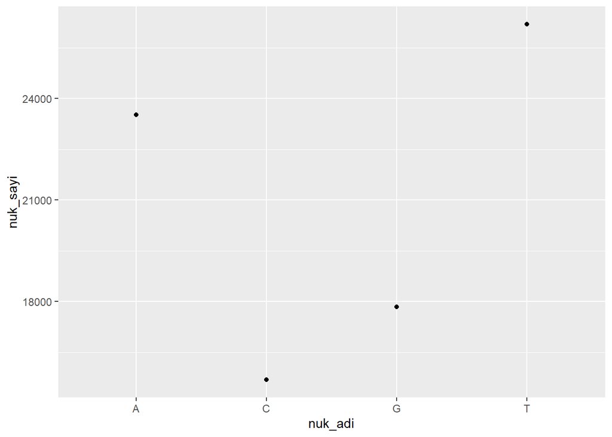

```r
# A T G C nin sayilarinin gorselle昼㹥tirilmesi :

pten_nuk_dizilim  <- data.frame(nuk_sayi =c(pten_paa_count,pten_pg_count ,pten_pc_count,pten_pt_count) , nuk_adi = c("A", "G","C","T"))


ggplot(pten_nuk_dizilim,aes(x=nuk_adi,y =nuk_sayi) ) +geom_point()
```

```r
library(readr)
nf1 <- read_csv("C:/Users/Dell/Dropbox/My PC (DESKTOP-EB8G4PC)/Desktop/NF1.txt")
nchar(nf1)
```

```
##   NF1
## 15326
```

```r
head(nf1)
```

| NF1 |
| --- |
| 1 aatctctagc tcgctcgcgc tccctctccc cgggccgtgg aaaggatccc acttccggtg |
| 61 gggtgtcatg gcggcgtctc ggactgtgat ggctgtgggg agacggcgct agtggggaga |
| 121 gcgaccaaga ggccccctcc cctccccggg tccccttccc ctatccccct ccccccagcc |
| 181 tccttgccaa cgcccccttt ccctctcccc ctcccgctcg gcgctgaccc cccatcccca |
| 241 cccccgtggg aacactggga gcctgcactc cacagaccct ctccttgcct cttccctcac |
| 301 ctcagcctcc gctccccgcc ctcttcccgg cccagggcgc cggcccaccc ttccctccgc |

```r
# nf1 genindeki t varyasyonlari
separator <- char_class(" ")
pattern_t_nf1 <- zero_or_more(separator) %R% one_or_more("t") %R%zero_or_more(separator)
nf1_pt <- str_extract(nf1, pattern=pattern_t_nf1)
table(nf1_pt)
```

```
## nf1_pt
## t
## 1
```

```r
# nf1 genindeki t sayisi
nf1_pt_count <- str_count(nf1, pattern=pattern_t_nf1)
nf1_pt_count <-sum(nf1_pt_count )

# nf1 genindeki a varyasyonlari

pattern_aa_nf1 <- zero_or_more(separator) %R% one_or_more("a") %R%zero_or_more(separator)
nf1_paa <- str_extract(nf1, pattern=pattern_aa_nf1)
table(nf1_paa)
```

```
## nf1_paa
##  aa
##   1
```

```r
# nf1 genindeki t sayisi
nf1_paa_count <- str_count(nf1, pattern=pattern_aa_nf1)
nf1_paa_count <-sum(nf1_paa_count)

# nf1 genindeki g varyasyonlari

pattern_g_nf1 <- zero_or_more(separator) %R% one_or_more("g") %R%zero_or_more(separator)
nf1_pg <- str_extract(nf1, pattern=pattern_g_nf1)
table(nf1_pg)
```

```
## nf1_pg
## g
## 1
```

```r
# nf1 genindeki g sayisi
nf1_pg_count <- str_count(nf1, pattern=pattern_g_nf1)
nf1_pg_count <- sum(nf1_pg_count)


# nf1 genindeki c varyasyonlari

pattern_c_nf1 <- zero_or_more(separator) %R% one_or_more("c") %R%zero_or_more(separator)
nf1_pc <- str_extract(nf1, pattern=pattern_c_nf1 )
table(nf1_pc )
```

```
## nf1_pc
## c
## 1
```

```r
# nf1 genindeki c sayisi
nf1_pc_count <- str_count(nf1, pattern=pattern_c_nf1)
nf1_pc_count <- sum(nf1_pc_count)

table(nf1_paa_count,nf1_pg_count ,nf1_pc_count ,nf1_pt_count )
```

```
## , , nf1_pc_count = 2030, nf1_pt_count = 2527
##
##              nf1_pg_count
## nf1_paa_count 1999
##          2546    1
```

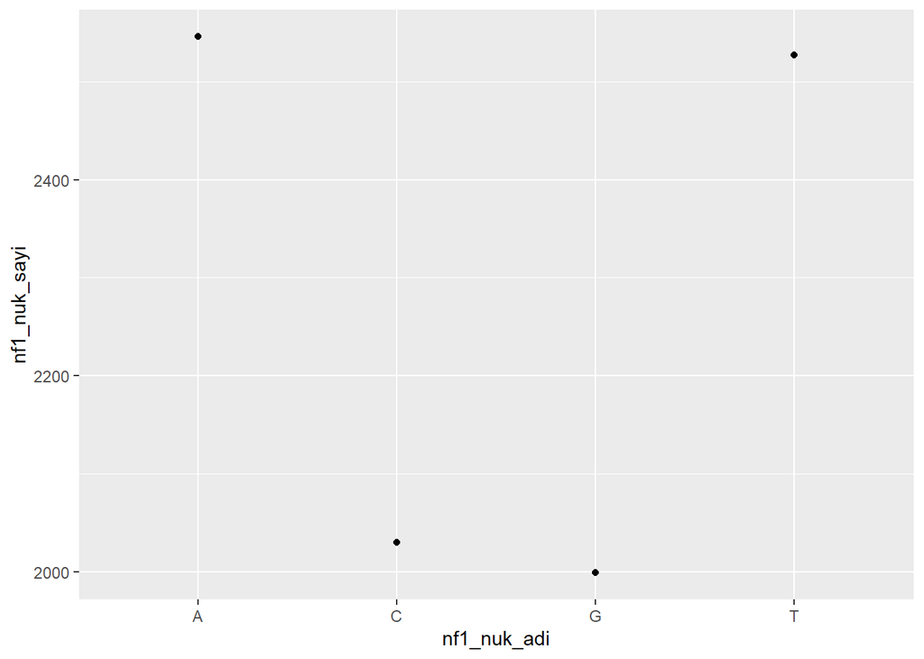

```r
# A T G C nin sayilarinin gorselle昼㹥tirilmesi :

nf1_nuk_dizilim  <- data.frame(nf1_nuk_sayi =c(nf1_paa_count,nf1_pg_count ,nf1_pc_count,nf1_pt_count) , nf1_nuk_adi = c("A", "G","C","T"))


ggplot(nf1_nuk_dizilim,aes(x=nf1_nuk_adi,y =nf1_nuk_sayi) ) +geom_point()
```

```r
pik<- read.table("C:/Users/Dell/Dropbox/My PC (DESKTOP-EB8G4PC)/Desktop/PIK3R1.txt", quote="\"")


# pik genindeki t varyasyonlari
separator <- char_class(" ")
pattern_t_pik <- zero_or_more(separator) %R% one_or_more("T") %R%zero_or_more(separator)
pik_pt <- str_extract(pik, pattern=pattern_t_pik)
table(pik_pt)
```

```
## pik_pt
## T
## 1
```

```r
# pik genindeki t sayisi
pik_pt_count <- str_count(pik, pattern=pattern_t_pik)
pik_pt_count <-sum(pik_pt_count )

# pik genindeki a varyasyonlari

pattern_aa_pik <- zero_or_more(separator) %R% one_or_more("A") %R%zero_or_more(separator)
pik_paa <- str_extract(pik, pattern=pattern_aa_pik)
table(pik_paa)
```

```
## pik_paa
## A
## 1
```

```r
# pik genindeki t sayisi
pik_paa_count <- str_count(pik, pattern=pattern_aa_pik)
pik_paa_count <-sum(pik_paa_count)

# pik genindeki g varyasyonlari

pattern_g_pik <- zero_or_more(separator) %R% one_or_more("G") %R%zero_or_more(separator)
pik_pg <- str_extract(pik, pattern=pattern_g_pik)
table(pik_pg)
```

```
## pik_pg
## G
## 1
```

```r
# pik genindeki g sayisi
pik_pg_count <- str_count(pik, pattern=pattern_g_pik)
pik_pg_count <- sum(pik_pg_count)


#pik genindeki c varyasyonlari

pattern_c_pik <- zero_or_more(separator) %R% one_or_more("C") %R%zero_or_more(separator)
pik_pc <- str_extract(pik, pattern=pattern_c_pik )
table(pik_pc )
```

```
## pik_pc
## C
## 1
```

```r
# pik genindeki c sayisi
pik_pc_count <- str_count(pik, pattern=pattern_c_pik)
pik_pc_count <- sum(pik_pc_count)

table(pik_paa_count,pik_pg_count ,pik_pc_count ,pik_pt_count )
```

```
## , , pik_pc_count = 184, pik_pt_count = 226
##
##              pik_pg_count
## pik_paa_count 223
##           296   1
```

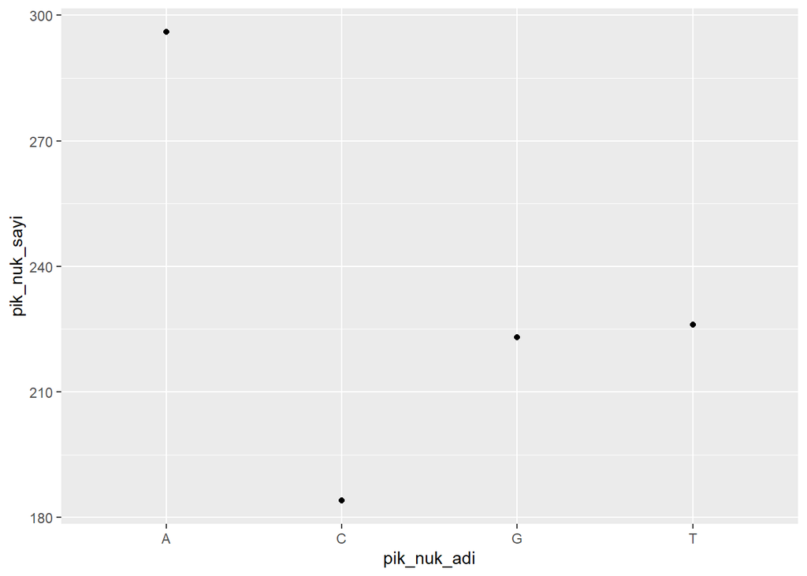

```r
# A T G C nin sayilarinin gorselle昼㹥tirilmesi :

pik_nuk_dizilim  <- data.frame(pik_nuk_sayi =c(pik_paa_count,pik_pg_count ,pik_pc_count,pik_pt_count) , pik_nuk_adi = c("A", "G","C","T"))


ggplot(pik_nuk_dizilim,aes(x=pik_nuk_adi,y =pik_nuk_sayi) ) +geom_point()
```

```r
egfr <- read_csv("C:/Users/Dell/Dropbox/My PC (DESKTOP-EB8G4PC)/Desktop/egfr.txt")


# egfr genindeki t varyasyonlari

pattern_t_egfr <- one_or_more("T")
egfr_pt <- str_extract(egfr, pattern=pattern_t_egfr)
table(egfr_pt)
```

```
## egfr_pt
## TT
##  1
```

```r
# egfr genindeki t sayisi
egfr_pt_count <- str_count(egfr, pattern=pattern_t_egfr)
egfr_pt_count <-sum(egfr_pt_count )

#egfr genindeki a varyasyonlari

pattern_aa_egfr <- one_or_more("A")
egfr_paa <- str_extract(egfr, pattern=pattern_aa_egfr)
table(egfr_paa)
```

```
## egfr_paa
## A
## 1
```

```r
# egfr genindeki t sayisi
egfr_paa_count <- str_count(egfr, pattern=pattern_aa_egfr)
egfr_paa_count <-sum(egfr_paa_count)

# egfr genindeki g varyasyonlari

pattern_g_egfr<-  one_or_more("G")
egfr_pg <- str_extract(egfr, pattern=pattern_g_egfr)
table(egfr_pg)
```

```
## egfr_pg
## G
## 1
```

```r
# egfr genindeki g sayisi
egfr_pg_count <- str_count(egfr, pattern=pattern_g_egfr)
egfr_pg_count <- sum(egfr_pg_count)


# egfr genindeki c varyasyonlari

pattern_c_egfr <- one_or_more("C")
egfr_pc <- str_extract(egfr, pattern=pattern_c_egfr )
table(egfr_pc )
```

```
## egfr_pc
## C
## 1
```

```r
# egfr genindeki c sayisi
egfr_pc_count <- str_count(egfr, pattern=pattern_c_egfr)
egfr_pc_count <- sum(egfr_pc_count)

table(egfr_paa_count,egfr_pg_count ,egfr_pc_count ,egfr_pt_count )
```

```
## , , egfr_pc_count = 1557, egfr_pt_count = 1681
##
##               egfr_pg_count
## egfr_paa_count 1557
##           1668    1
```

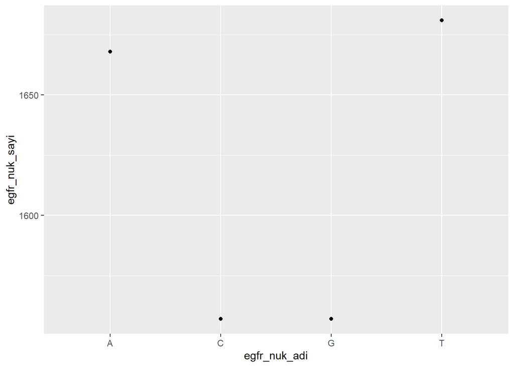

```r
# A T G C nin sayilarinin gorselle昼㹥tirilmesi :

egfr_nuk_dizilim  <- data.frame(egfr_nuk_sayi =c(egfr_paa_count,egfr_pg_count ,egfr_pc_count,egfr_pt_count) , egfr_nuk_adi = c("A", "G","C","T"))


ggplot(egfr_nuk_dizilim,aes(x=egfr_nuk_adi,y =egfr_nuk_sayi) ) +geom_point()
```

```r
tp53 <- read_csv("C:/Users/Dell/Dropbox/My PC (DESKTOP-EB8G4PC)/Desktop/tp53.txt")

# tp53 genindeki t varyasyonlari

pattern_t_tp53 <- one_or_more("T")
tp53_pt <- str_extract(tp53, pattern=pattern_t_tp53)
table(tp53_pt)
```

```
## tp53_pt
## T
## 1
```

```r
# tp53 genindeki t sayisi
tp53_pt_count <- str_count(tp53, pattern=pattern_t_tp53)
tp53_pt_count <-sum(tp53_pt_count )

# tp53 genindeki a varyasyonlari

pattern_aa_tp53 <- one_or_more("A")
tp53_paa <- str_extract(tp53, pattern=pattern_aa_tp53)
table(tp53_paa)
```

```
## tp53_paa
## A
## 1
```

```r
# tp53 genindeki t sayisi
tp53_paa_count <- str_count(tp53, pattern=pattern_aa_tp53)
tp53_paa_count <-sum(tp53_paa_count)

# tp53 genindeki g varyasyonlari

pattern_g_tp53<-  one_or_more("G")
tp53_pg <- str_count(tp53, pattern=pattern_g_tp53)
table(tp53_pg)
```

```
## tp53_pg
## 228
##   1
```

```r
# tp53 genindeki g sayisi
tp53_pg_count <- str_count(tp53, pattern=pattern_g_tp53)
tp53_pg_count <- sum(tp53_pg_count)


# tp53 genindeki c varyasyonlari

pattern_c_tp53<- one_or_more("C")
tp53_pc <- str_extract(tp53, pattern=pattern_c_tp53 )
table(tp53_pc )
```

```
## tp53_pc
## CC
##  1
```

```r
# tp53 genindeki c sayisi
tp53_pc_count <- str_count(tp53, pattern=pattern_c_tp53)
tp53_pc_count <- sum(tp53_pc_count)

table(tp53_paa_count,tp53_pg_count ,tp53_pc_count ,tp53_pt_count )
```

```
## , , tp53_pc_count = 229, tp53_pt_count = 189
##
##               tp53_pg_count
## tp53_paa_count 228
##            213   1
```

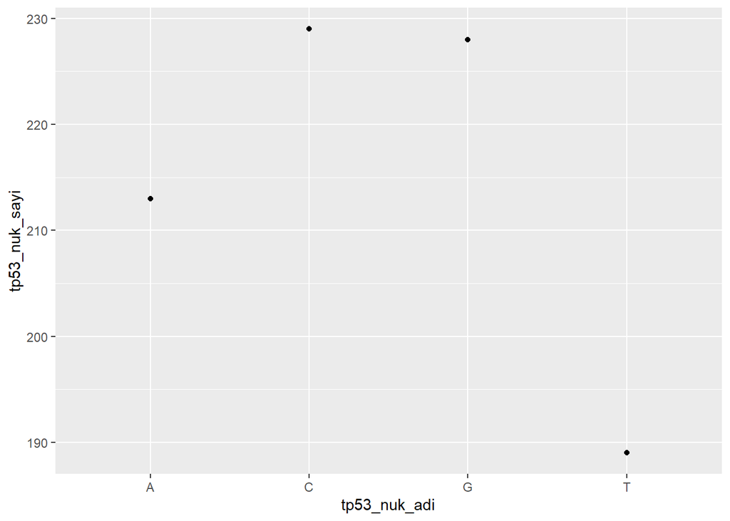

```r
# A T G C nin sayilarinin gorselle昼㹥tirilmesi :

tp53_nuk_dizilim  <- data.frame(tp53_nuk_sayi =c(tp53_paa_count,tp53_pg_count ,tp53_pc_count,tp53_pt_count) , tp53_nuk_adi = c("A", "G","C","T"))


ggplot(tp53_nuk_dizilim,aes(x=tp53_nuk_adi,y =tp53_nuk_sayi) ) +geom_point()
```

```r
# PTEN geni kombinasyonlarina bakma :
head(pten1,30)
```

```
##  [1] "        1 aggtgctgtt ttttgtgatg ccttagaggc cagaaggatg ttttgaaggg gaaaattgta"
##  [2] "       61 ggagttaggc agagcagggt tttggctcct tctcaatgtc cctctaccta gacaaattcg"
##  [3] "      121 ggctattctg cagaggttgc agtgagccat gatcacgtca ctgcactcca gcctgaggaa"
##  [4] "      181 cagagggaga ctccgtctca aaaaaaaaaa aaaaaaaaaa aaaaaaaaaa atttctgcct"
##  [5] "      241 actctatgaa gcacctggta ggtgtcccaa tattttctgg tatatgggaa ttaccttttt"
##  [6] "      301 ctattattgg aaggtctaaa aagcaaacaa tgtgctccat atggctagag ttagtattaa"
##  [7] "      361 ggggaccaag tagaataatt ggtagctagt gttagcctgg agactaacat agtcaaagct"
##  [8] "      421 gtcttgtcat gttatgtctt ttttatttgt attgctccac ggtccaagac aaaatttctg"
##  [9] "      481 aacgccactt ggacacagtg agtacctggt ctgctctatt gttctcagga gcaaccaact"
## [10] "      541 caacccttat ttctctgaga atgatgattt catacagcac atctctctac caagatgtga"
## [11] "      601 aagatgacac catggcatct gaaatagctt caggagagat ttgggacatg ggaagcttgt"
## [12] "      661 agacaataat ggaaaattct cttttagaat atagttactt gtatgaccca cagtagcgcc"
## [13] "      721 ttttggagaa tgtcttaaaa ttatctttat tgaaagaaca ataatgtttg ttattaggat"
## [14] "      781 aaatgaaata aggggaaaac ctcagaccct tggaacaatg ggtttacatt caatccaatg"
## [15] "      841 attattatgt ttttatattc tgtattattt agaaaacagt agttaaacag acagaaatac"
## [16] "      901 agaagattgt ttaaaaatta aagctattga gttagatccc tttttgaaag gtcagcgtat"
## [17] "      961 gggagatgag aaaggcacta tagagatcag agtgtttaca caaaagacat cttagcagat"
## [18] "     1021 gacctacaaa gagcacatca agtatttata tcatccacat caagttgctg gtcatttcgc"
## [19] "     1081 ttatcaaaga aaataagaaa gaaattttct ttcgacatta ttttggtgta gtaacaatag"
## [20] "     1141 agttttggaa tcagctgtta gaagcgataa ttaaagctag tttaccatgc ttactaatca"
## [21] "     1201 atctacatag tcaccctgaa gctttatata attgtccctt tgttacaagc ttctacttct"
## [22] "     1261 ccctatggta ttctggttct gaatccagac aggtaaagaa ctaagtatgg ccgggcgcgg"
## [23] "     1321 tggctcacgc ctgtaatccc agcactttgg gaggccgtgg cgggcagatc acgaggtcag"
## [24] "     1381 gagatcgaga ccatcctgac caacatggtg aaaccctgtc tttactaaac tacaaaaaat"
## [25] "     1441 tagcccggca tgatggtgtg cgcctgtagt cccagctact cgggaggctg aggcagggga"
## [26] "     1501 attgcttgaa cctgggaggc agaggttgca gtgaaccgag atcatgccac tgcactccag"
## [27] "     1561 cctgtgagac tccgtctcaa aaaaaaaaaa aaaaaaagaa aaaaaaaaaa agaactgaag"
## [28] "     1621 tgcttggaga ccagtgtatt gtaatatcta tacagccaag caggtatttt caactgaact"
## [29] "     1681 ttaaaaaagt actatttttg aaactttctt tagtttagat agggccagcc atttgggtag"
## [30] "     1741 aaaggaaaag aaaaacaaaa aattggaaaa ggatgcatca gtatttcttt cagaaacaac"
```

```r
separator <- char_class(" ")
 # 1
pattern_1_pten <- zero_or_more(separator) %R% c("aggtgctgtt","ttttgtgatg","ccttagaggc") %R%zero_or_more(separator)

pten_p1 <- str_extract(pten1, pattern=pattern_1_pten)
table(pten_p1)
```

```
## pten_p1
##  aggtgctgtt
##            1
```

```r
# 2
pattern_2_pten <- zero_or_more(separator) %R% "ttttgtgatg" %R%zero_or_more(separator)

pten_p2 <- str_extract(pten1, pattern=pattern_2_pten)
table(pten_p2)
```

```
## pten_p2
##  ttttgtgatg
##            1
```

```r
# 3
pattern_3_pten <- zero_or_more(separator) %R% "ccttagaggc" %R%zero_or_more(separator)

pten_p3 <- str_extract(pten1, pattern=pattern_3_pten)
table(pten_p3)
```

```
## pten_p3
##  ccttagaggc
##            1
```

```r
#4
pattern_4_pten <- zero_or_more(separator) %R% "atggctagag" %R%zero_or_more(separator)

pten_p4 <- str_extract(pten1, pattern=pattern_4_pten)
table(pten_p4)
```

```
## pten_p4
##  atggctagag
##            1
```

```r
# 7
patten7 <- one_or_more("tgc") %R% zero_or_more("a") %R% one_or_more("tc")

str_view(pten1, pattern = patten7, match = TRUE)
```

[interactive chart not shown]

```r
#8
patten8 <- ("t") %R% ("a") %R% ("t")

str_view(pten1, pattern = patten8, match = TRUE)
```

[interactive chart not shown]

```r
pattern_2_nf1 <- zero_or_more(separator) %R% "atggctagag" %R%zero_or_more(separator)

nf1_p2 <- str_extract(nf1, pattern=pattern_2_nf1)
table(nf1_p2)
```

```
## < table of extent 0 >
```